# 611_Final

# Median total gross pay by NYC borough (2015–2020)

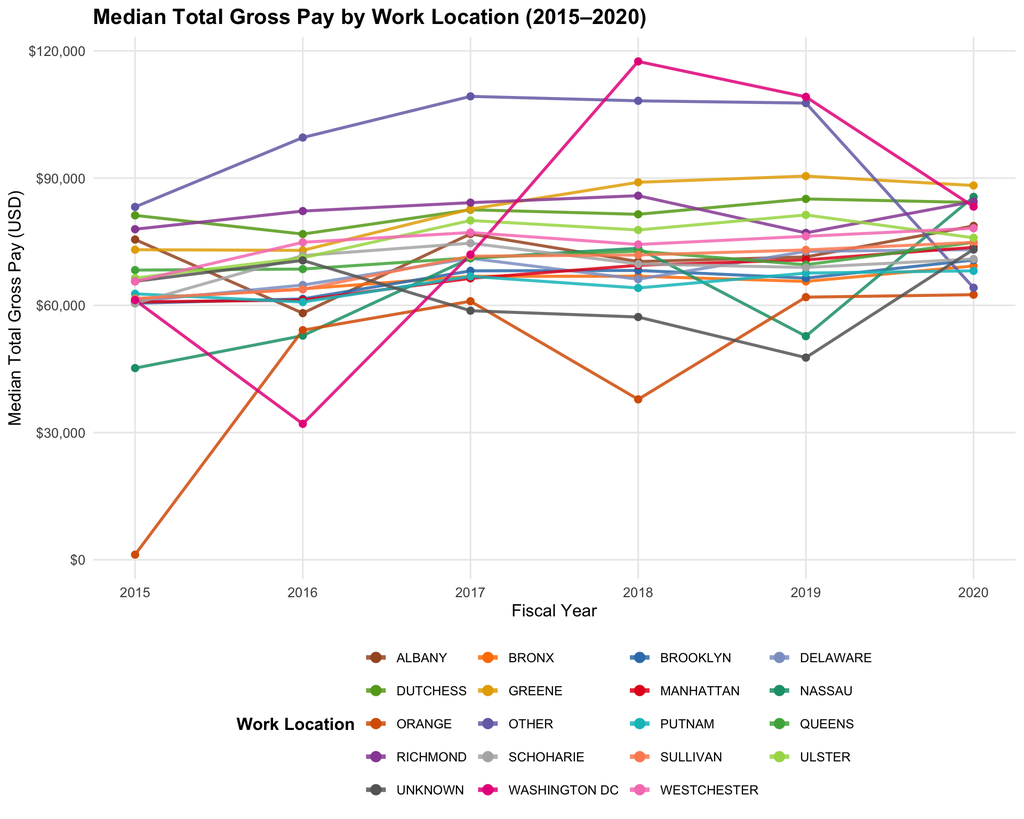

```r
# Prepare data
fig5_data <- payroll %>%
  mutate(
    borough = toupper(trimws(`Work Location Borough`)),
    borough = ifelse(is.na(borough), "UNKNOWN", borough),
    total_pay = coalesce(`Regular Gross Paid`, 0) +
                coalesce(`Total OT Paid`, 0) +
                coalesce(`Total Other Pay`, 0)
  ) %>%
  filter(
    `Fiscal Year` %in% 2015:2020,
    total_pay > 0,
    grepl("annual|annum", `Pay Basis`, ignore.case = TRUE)
  ) %>%
  group_by(`Fiscal Year`, borough) %>%
  summarise(
    median_pay = median(total_pay),
    .groups = "drop"
  )

# Manually assign colors
location_colors <- c(
  # Five NYC boroughs: strong, distinct colors
  "MANHATTAN"     = "#E41A1C",  # Red
  "BROOKLYN"      = "#377EB8",  # Blue
  "QUEENS"        = "#4DAF4A",  # Green
  "BRONX"         = "#FF7F00",  # Orange
  "RICHMOND"      = "#984EA3",  # Purple

  # Other locations
  "ALBANY"        = "#A65628",  # Brown
  "DELAWARE"      = "#8DA0CB",  # Light blue
  "DUTCHESS"      = "#66A61E",  # Olive
  "GREENE"        = "#E6AB02",  # Gold
  "NASSAU"        = "#1B9E77",  # Teal
  "ORANGE"        = "#D95F02",  # Dark orange
  "OTHER"         = "#7570B3",  # Lavender
  "PUTNAM"        = "#00BFC4",  # Cyan
  "SCHOHARIE"     = "#B3B3B3",  # Gray
  "SULLIVAN"      = "#FC8D62",  # Coral
  "ULSTER"        = "#A6D854",  # Lime
  "UNKNOWN"       = "#666666",  # Dark gray
  "WASHINGTON DC" = "#E7298A",  # Magenta
  "WESTCHESTER"   = "#F781BF"   # Pink
)

# Plot
ggplot(
  fig5_data,
  aes(
    x = `Fiscal Year`,
    y = median_pay,
    color = borough,
    group = borough
  )
) +
  geom_line(linewidth = 1, alpha = 0.85) +
  geom_point(size = 2) +
  scale_color_manual(values = location_colors) +
  scale_x_continuous(breaks = 2015:2020) +
  scale_y_continuous(labels = label_dollar()) +
  labs(
    title = "Median Total Gross Pay by Work Location (2015–2020)",
    x = "Fiscal Year",
    y = "Median Total Gross Pay (USD)",
    color = "Work Location"
  ) +
  guides(
    color = guide_legend(
      ncol = 4,
      byrow = TRUE,
      override.aes = list(linewidth = 1.5, size = 3)
    )
  ) +
  theme_minimal(base_size = 12) +
  theme(
    plot.title = element_text(face = "bold", size = 15),
    legend.position = "bottom",
    legend.title = element_text(face = "bold"),
    legend.text = element_text(size = 9),
    panel.grid.minor = element_blank()
  )
```

Median total gross pay varies across work locations, although most locations remain within approximately $60,000 to $90,000 throughout the study period. Several locations exhibit relatively stable compensation patterns, while others show substantial fluctuations. For example, Washington DC displays considerable variation, reaching nearly $120,000 in 2018 before declining in subsequent years. In contrast, the five NYC boroughs generally show more moderate changes over time. These findings suggest geographical differences in employee compensation, potentially influenced by agency distribution, job characteristics, and workforce composition. However, locations with smaller employee populations may exhibit greater year-to-year variability.

# Conclusion

NYC payroll expenditures and median salaries increased between 2015 and 2020, while compensation varied considerably across agencies, salary levels, and work locations. The results provide descriptive evidence of differences in NYC government employee compensation, although further analysis would be needed to determine the underlying causes of these patterns.